# Projeto de Capacidade Produtiva

Etapa V - Modelagem dos dados - 2012 a 2019 - SP - (Y31D-OUTROS SERVIÇOS)

Allan B. Martins

23 maio 2022

# 1 Contextualização

O banco de dados analisado traz os dados de instrumentos, força de trabalho e despesa de custeio da série temporal de **2012 a 2019** e utilizando por meio da **Regressão Linear Múltipla**, para cada **UF**, serão rodados 81 modelos de Regressão Linear Múltipla, ou seja, um modelo por UF, para cada um dos 81 itens do Plano de Planejamnto de Técnico. Ao todo, serão 26 UF x 81 modelos, totalizando-se 2.106 modelos de regressão rodados, nessa primeira fase de modelagem o objetivo é entregar aos colegas dos Escritórios, os resultados da saída **“summary”**, bem como as análises de resíduos [**testes de normalidade**, **testes de homocedasticidade**, **teste de independência dos resíduos**] e os respectivos **gráficos de resíduos**.

# 2 Carregamento dos pacotes

```r
library(dplyr)
library(readxl)
library(rstatix)
library(emmeans)
library(ggplot2)
library(knitr)
library(kableExtra)
library(htmltools)
library(zoo)
library(lmtest)
library(rmarkdown)
library(cowplot)
```

# 3 Leitura e visualização do banco de dados

```
## Rows: 8
## Columns: 5
## $ ANO        <dbl> 2012, 2013, 2014, 2015, 2016, 2017, 2018, 2019
## $ UF         <chr> "SP", "SP", "SP", "SP", "SP", "SP", "SP", "SP"
## $ X1FTINST   <dbl> 287, 281, 321, 305, 369, 368, 367, 272
## $ X2CusteioT <dbl> 18775593, 18775593, 22459448, 18542184, 17734431, 18601406,~
## $ Y31D       <dbl> 31673, 29205, 3590, 1010, 918, 577, 470, 492
```

| ANO | UF | FORÇA DE TRABALHO PERIÓDICA | DESPESA DE CUSTEIO | OUTROS SERVIÇOS |
| --- | --- | --- | --- | --- |
| 2012 | SP | 287 | 18775593 | 31673 |
| 2013 | SP | 281 | 18775593 | 29205 |
| 2014 | SP | 321 | 22459448 | 3590 |
| 2015 | SP | 305 | 18542184 | 1010 |
| 2016 | SP | 369 | 17734431 | 918 |
| 2017 | SP | 368 | 18601406 | 577 |
| 2018 | SP | 367 | 22899213 | 470 |
| 2019 | SP | 272 | 18263763 | 492 |

# 4 A UF (**SP**) e o item do Plano de trabalho (**Y31D - OUTROS SERVIÇOS**) que estão sendo analisados nos teste a seguir.

## 4.1 Ajustar o modelo linear com intercepto

### 4.1.1 Estatística de descritivas

```r
options(scipen=999)
Mod1<-lm(Y31D~X1FTINST+X2CusteioT, bdcp_2012_2019) #Ajustar o modelo linear com intercepto
summary(Mod1)   #Obter as estatísticas descritivas do modelo ajustado
```

```
##
## Call:
## lm(formula = Y31D ~ X1FTINST + X2CusteioT, data = bdcp_2012_2019)
##
## Residuals:
##        1        2        3        4        5        6        7        8
##  16821.6  13273.9  -4154.5 -10664.8    543.4    255.1   1121.3 -17196.0
##
## Coefficients:
##                  Estimate    Std. Error t value Pr(>|t|)
## (Intercept) 71535.8382699 56190.4790297   1.273    0.259
## X1FTINST     -179.9526002   126.2762719  -1.425    0.213
## X2CusteioT     -0.0002683     0.0026313  -0.102    0.923
##
## Residual standard error: 13320 on 5 degrees of freedom
## Multiple R-squared:  0.3146, Adjusted R-squared:  0.04038
## F-statistic: 1.147 on 2 and 5 DF,  p-value: 0.389
```

### 4.1.2 Gráfico de dispersão

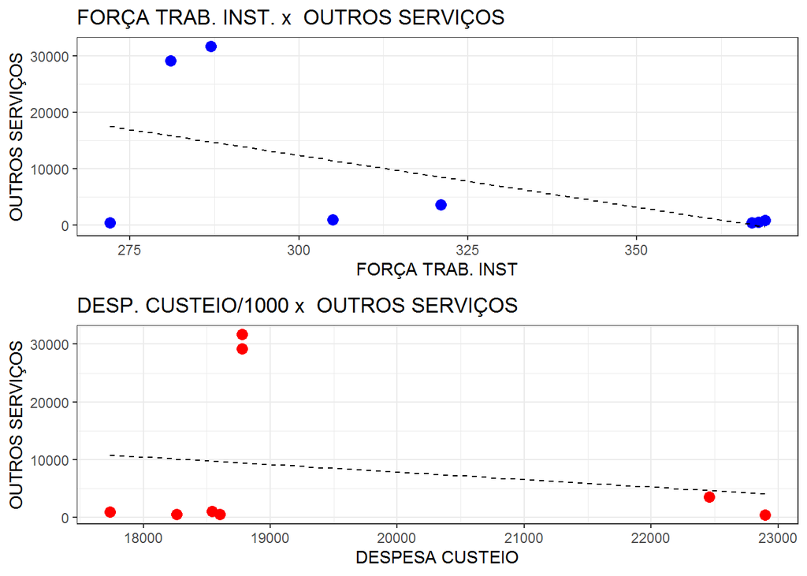

## 4.2 Proceder à análise de resíduos

### 4.2.1 Gráfico de resíduos

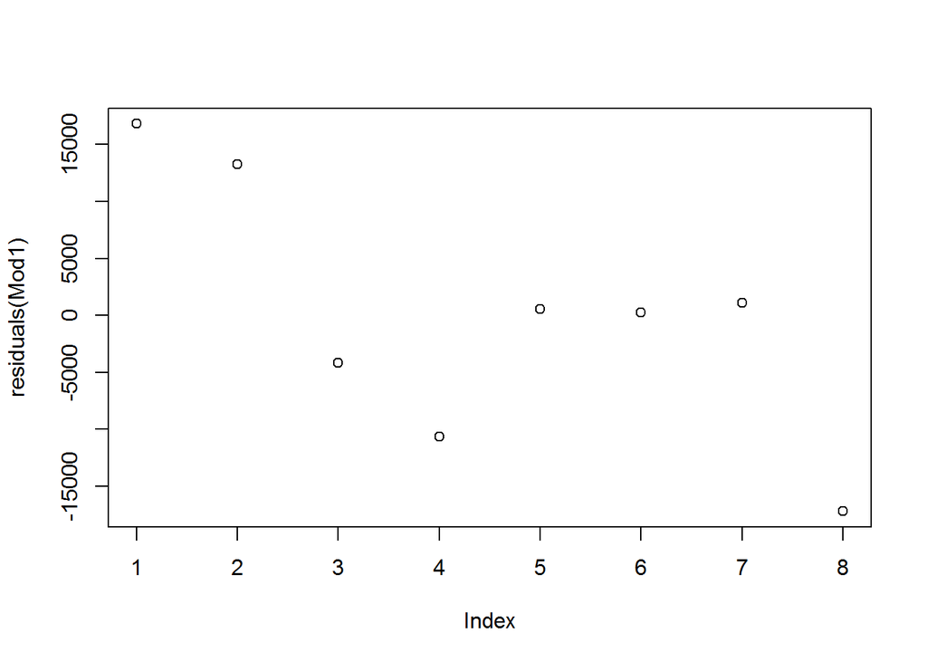

## 4.3 Testar normalidade dos resíduos

### 4.3.1 Resultado

```r
shapiro.test(residuals(Mod1))
```

```
##
##  Shapiro-Wilk normality test
##
## data:  residuals(Mod1)
## W = 0.95383, p-value = 0.7497
```

### 4.3.2 Crítérios de avaliação

H0: distribuição dos dados = normal -> p > 0.05.  
H1: distribuição dos dados ≠ normal -> p ≤ 0,05.

## 4.4 Teste de homocedasticidade:

### 4.4.1 Teste de Goldefeld-Quandt

#### 4.4.1.1 Resultado

```r
gqtest(Mod1)
```

```
##
##  Goldfeld-Quandt test
##
## data:  Mod1
## GQ = 0.00077739, df1 = 1, df2 = 1, p-value = 0.9823
## alternative hypothesis: variance increases from segment 1 to 2
```

#### 4.4.1.2 Interpretação e crítérios de avaliação

**Aqui está como interpretar a saída:**

A estatística de teste é resultado de “GQ”.  
O valor p correspondente é resultado de “p”.

**crítérios de avaliação:**

O teste Goldfeld-Quandt usa as seguintes hipóteses nulas e alternativas:

Nulo (H 0 ) : Homocedasticidade está presente.  
Alternativa (H A ): Heteroscedasticidade está presente.

Se o valor p não é inferior a 0,05, falhamos em rejeitar a hipótese nula. Não temos evidências suficientes para dizer que a heterocedasticidade está presente no modelo de regressão.

### 4.4.2 Teste de independência dos resíduos

```r
dwtest(Mod1)
```

```
##
##  Durbin-Watson test
##
## data:  Mod1
## DW = 0.92475, p-value = 0.0479
## alternative hypothesis: true autocorrelation is greater than 0
```

### 4.4.3 Inserir gráficos para avaliar os resíduos

#### 4.4.3.1 Análise gráfica

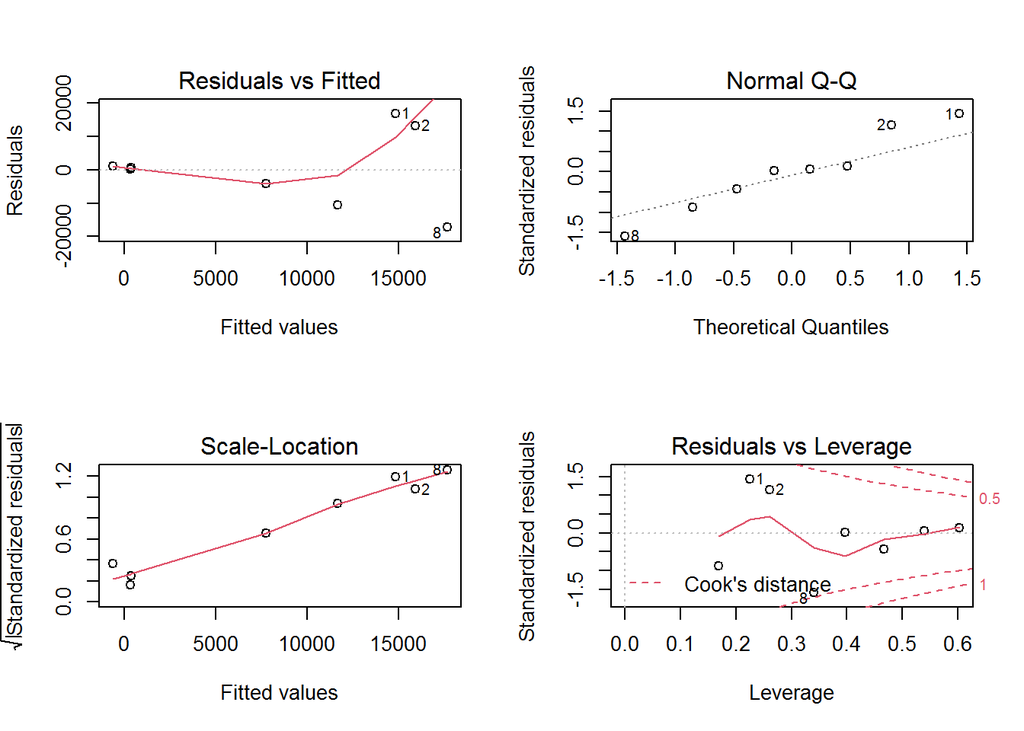

#### 4.4.3.2 Considerações sobre os gráficos

1º Gráfico (da direita para a esquerda 1ª linha) é pelos resíduos pelos valores ajustados e serve para avaliar o pressuposto de **linearidade** com a linha vermelha aproximadamente na horizontal.

2º Gráfico (da direita para a esquerda 1ª linha) apresenta se os resíduos apresentam **distribuição normal** seguindo a linha pontilhada.

3º Gráfico (da direita para a esquerda 2ª linha) apresenta a **homocedasticidade**, se houver, os pontos tem que estar dispersos em um padrão meio que retangular, não pode haver um padrão triangular.

4º Gráfico (da direita para a esquerda 2ª linha) apresenta se existem **outliers** e **pontos influentes**, caso existam, vai haver uma linha pontilhada vermelha com esses pontos para fora .

### 4.4.4 Inserir gráfico do observado (y) versus predito

[figure not shown]

## 4.5 Agregar os resultados no data.frame

| X1FTINST…X2CusteioT | OUTROS SERVIÇOS | Mod1.fitted.values | Mod1.residual |
| --- | --- | --- | --- |
| 18775880 | 31673 | 14851.3643 | 16821.6357 |
| 18775874 | 29205 | 15931.0799 | 13273.9201 |
| 22459769 | 3590 | 7744.4826 | -4154.4826 |
| 18542489 | 1010 | 11674.8484 | -10664.8484 |
| 17734800 | 918 | 374.6273 | 543.3727 |
| 18601774 | 577 | 321.9435 | 255.0565 |
| 22899580 | 470 | -651.3395 | 1121.3395 |
| 18264035 | 492 | 17687.9934 | -17195.9934 |

# 5 Material de Apoio

- Regressão linear múltipla no R: [Fernanda Peres](https://youtu.be/4YLOwyx_hxo)
- PLAYLIST - Criando gráficos no R com o ggplot2 (Parte 1 ao 2): [Fernanda Peres](https://youtu.be/DYsPRa3vpf0)
- PLAYLIST - R Markdown: Gerando relatórios usando o R (Parte 1 ao 5): [Fernanda Peres](https://youtu.be/obxa5VH4WvY)
- Minicurso R - UFPR: [UFPR](https://youtu.be/obxa5VH4WvY)

# 6 Créditos - Participantes do Projeto Capacidade Produtiva: